# Descriptive Statistics

2026-06-18

# Dataset Overview

This report describes the current raw vignette dataset at the **case level**. The raw file has one row per model response, so patient characteristics are first deduplicated to one row per `case_id`.

Dataset Overview

| Metric | Value |
| --- | --- |
| Raw model-response rows | 300 |
| Unique cases | 100 |
| Unique models | 3 |
| Cases with exactly 3 model responses | 100 |
| Duplicate case-model combinations | 0 |

Model Response Rows

| Model | Response rows | % |
| --- | --- | --- |
| azure/gpt-5.4 | 100 | 33.3 |
| bedrock/us.anthropic.claude-opus-4-6-v1 | 100 | 33.3 |
| bedrock/us.anthropic.claude-sonnet-4-6 | 100 | 33.3 |

**Key Takeaway:** The current raw file contains 300 responses from 100 unique cases and 3 models. Each case has the expected 3 model responses.

# Table 1. Case Characteristics

This table summarizes the variables most likely to be used in the manuscript description of the synthetic vignette population. Continuous variables are shown as mean (SD); median [Q1, Q3]. Categorical variables are shown as n (%).

Table 1. Case Characteristics

| Characteristic | Summary, n = 100 cases |
| --- | --- |
| <strong>Demographics</strong> |  |
| Age, years | 72.6 (6); 72 [68, 77] |
| Female sex | 52 (52%) |
| <strong>Race / ethnicity</strong> |  |
| &nbsp;&nbsp;Asian | 18 (18%) |
| &nbsp;&nbsp;Black | 30 (30%) |
| &nbsp;&nbsp;Hispanic | 20 (20%) |
| &nbsp;&nbsp;White | 32 (32%) |
| <strong>Diabetes and metabolic profile</strong> |  |
| Diabetes duration, years | 5.8 (6.6); 3 [0, 11] |
| HbA1c, % | 8.3 (0.7); 8.2 [7.9, 8.7] |
| BMI, kg/m2 | 31.3 (3.7); 31 [29, 34] |
| eGFR, mL/min/1.73m2 | 58.6 (21.5); 58 [38, 78] |
| UACR, mg/g | 152.8 (147); 74 [26, 265] |
| <strong>eGFR band</strong> |  |
| &nbsp;&nbsp;30-44 | 20 (20%) |
| &nbsp;&nbsp;45-59 | 19 (19%) |
| &nbsp;&nbsp;<30 | 13 (13%) |
| &nbsp;&nbsp;>=60 | 48 (48%) |
| <strong>Albuminuria band</strong> |  |
| &nbsp;&nbsp;30-299 | 50 (50%) |
| &nbsp;&nbsp;<30 | 30 (30%) |
| &nbsp;&nbsp;>=300 | 20 (20%) |
| <strong>Baseline diabetes medications</strong> |  |
| &nbsp;&nbsp;No diabetes medication | 49 (49%) |
| &nbsp;&nbsp;GLP-1 RA / GIP-GLP-1 | 19 (19%) |
| &nbsp;&nbsp;Metformin | 17 (17%) |
| &nbsp;&nbsp;SGLT2 inhibitor | 13 (13%) |
| &nbsp;&nbsp;Basal insulin | 6 (6%) |
| &nbsp;&nbsp;DPP-4 inhibitor | 2 (2%) |
| &nbsp;&nbsp;Prandial insulin | 2 (2%) |
| &nbsp;&nbsp;Sulfonylurea | 1 (1%) |
| <strong>Comorbidities and preferences</strong> |  |
| Chronic kidney disease | 55 (55%) |
| Heart failure | 12 (12%) |
| Hypertension | 100 (100%) |
| Hyperlipidemia | 93 (93%) |
| Coronary artery disease | 20 (20%) |
| MI history | 12 (12%) |
| Stroke/TIA history | 2 (2%) |
| Any cancer history | 13 (13%) |
| Financial limitations | 6 (6%) |
| Reluctant injections | 12 (12%) |

**Manuscript Emphasis:** This table should support the background statement that the vignette set intentionally focuses on older adults with type 2 diabetes and substantial prescribing complexity, especially kidney disease, albuminuria, baseline medication use, cardiovascular comorbidity, cancer history, and patient preferences that can affect medication choice.

# Continuous Case Characteristics

Continuous Characteristics (n = 100 cases)

| Variable | N | Mean | SD | Median | Q1 | Q3 | Min | Max |
| --- | --- | --- | --- | --- | --- | --- | --- | --- |
| Age | 100 | 72.6 | 6.0 | 72.0 | 68.0 | 77.0 | 65.0 | 86.0 |
| Diabetes duration, years | 99 | 5.8 | 6.6 | 3.0 | 0.0 | 11.0 | 0.0 | 24.0 |
| HbA1c, % | 100 | 8.3 | 0.7 | 8.2 | 7.9 | 8.7 | 6.8 | 10.4 |
| eGFR, mL/min/1.73m2 | 100 | 58.6 | 21.5 | 58.0 | 38.0 | 78.0 | 20.0 | 94.0 |
| UACR, mg/g | 100 | 152.8 | 147.0 | 74.0 | 26.0 | 265.0 | 10.0 | 520.0 |
| Creatinine, mg/dL | 100 | 1.3 | 0.5 | 1.2 | 0.9 | 1.6 | 0.8 | 2.9 |
| BMI, kg/m2 | 100 | 31.3 | 3.7 | 31.0 | 29.0 | 34.0 | 24.0 | 39.0 |
| SBP, mmHg | 100 | 135.6 | 5.9 | 136.0 | 130.0 | 140.0 | 124.0 | 148.0 |
| DBP, mmHg | 100 | 78.4 | 4.0 | 78.0 | 74.0 | 82.0 | 72.0 | 86.0 |
| LDL cholesterol, mg/dL | 100 | 105.4 | 10.6 | 106.0 | 97.0 | 113.0 | 79.0 | 126.0 |
| Triglycerides, mg/dL | 100 | 189.2 | 27.8 | 182.0 | 172.0 | 204.0 | 136.0 | 256.0 |

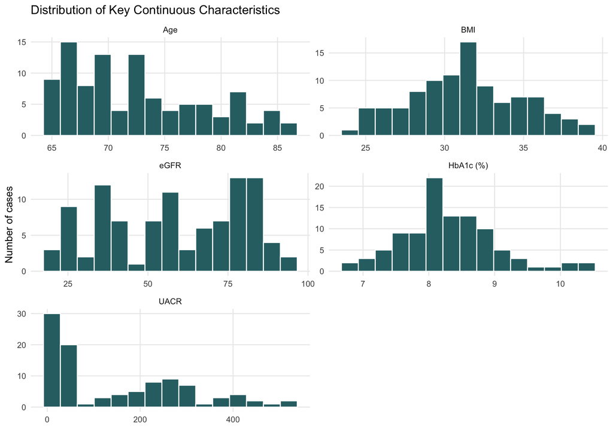

# Demographic Characteristics

Demographic Characteristics (n = 100 cases)

| Variable | Category | n | % |
| --- | --- | --- | --- |
| Sex | female | 52 | 52 |
|  | male | 48 | 48 |
| Race / ethnicity | White | 32 | 32 |
|  | Black | 30 | 30 |
|  | Hispanic | 20 | 20 |
|  | Asian | 18 | 18 |

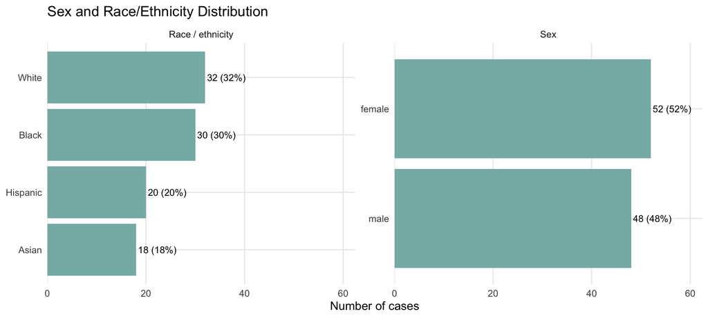

# Clinical Subgroup Distributions

Clinical Subgroup Distributions (n = 100 cases)

| Variable | Category | n | % |
| --- | --- | --- | --- |
| HbA1c band | 8-8.9 | 58 | 58 |
|  | 7-7.9 | 26 | 26 |
|  | 9-9.9 | 10 | 10 |
|  | >=10 | 4 | 4 |
|  | <7 | 2 | 2 |
| eGFR band | >=60 | 48 | 48 |
|  | 30-44 | 20 | 20 |
|  | 45-59 | 19 | 19 |
|  | <30 | 13 | 13 |
| Albuminuria band | 30-299 | 50 | 50 |
|  | <30 | 30 | 30 |
|  | >=300 | 20 | 20 |
| CKD stage | >=60 | 45 | 45 |
|  | 3 | 41 | 41 |
|  | 4 | 13 | 13 |
|  | 2 | 1 | 1 |

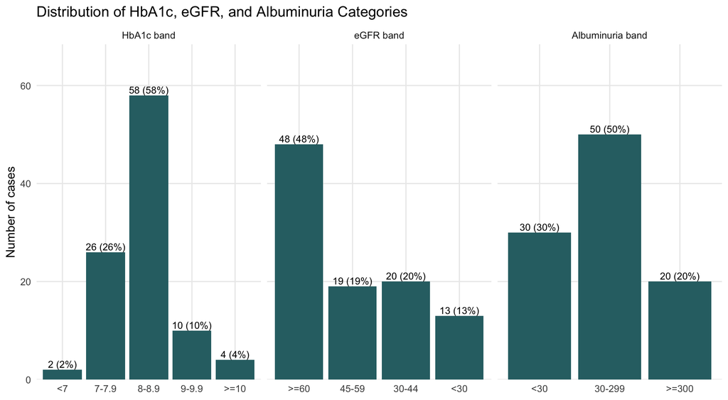

**Key Takeaway:** The vignette set includes many patients with clinically important kidney disease and albuminuria, which are central to diabetes medication selection.

# Comorbidities and Preferences

Comorbidities and Preferences (n = 100 cases)

| Variable | n | % |
| --- | --- | --- |
| Hypertension | 100 | 100 |
| Hyperlipidemia | 93 | 93 |
| Chronic kidney disease | 55 | 55 |
| Coronary artery disease | 20 | 20 |
| Preference: simple regimen | 17 | 17 |
| MASLD | 15 | 15 |
| Any cancer history | 13 | 13 |
| Heart failure | 12 | 12 |
| MI history | 12 | 12 |
| Reluctant injections | 12 | 12 |
| Osteoporosis | 11 | 11 |
| GU infection history | 8 | 8 |
| Anemia | 7 | 7 |
| Depression | 6 | 6 |
| Financial limitations | 6 | 6 |
| Preference: tighter control | 5 | 5 |
| Peripheral neuropathy | 3 | 3 |
| GI distress history | 3 | 3 |
| Stroke/TIA history | 2 | 2 |
| Diabetic retinopathy | 2 | 2 |
| MASH | 1 | 1 |
| COPD | 0 | 0 |
| Asthma | 0 | 0 |

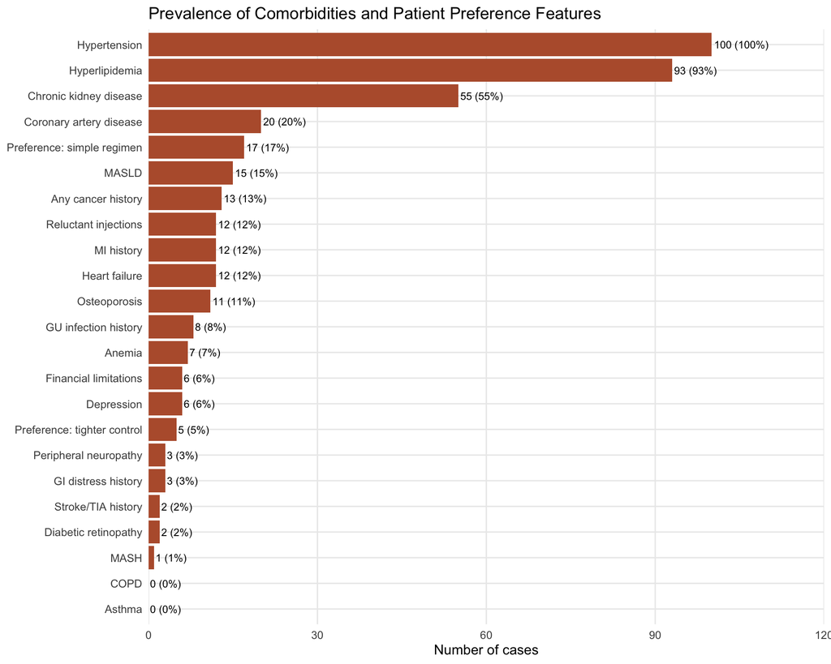

# Baseline Diabetes Medications

Baseline Diabetes Medications (n = 100 cases; classes overlap)

| Drug class | n | % |
| --- | --- | --- |
| No diabetes medication | 49 | 49 |
| GLP-1 RA / GIP-GLP-1 | 19 | 19 |
| Metformin | 17 | 17 |
| SGLT2 inhibitor | 13 | 13 |
| Basal insulin | 6 | 6 |
| DPP-4 inhibitor | 2 | 2 |
| Prandial insulin | 2 | 2 |
| Sulfonylurea | 1 | 1 |

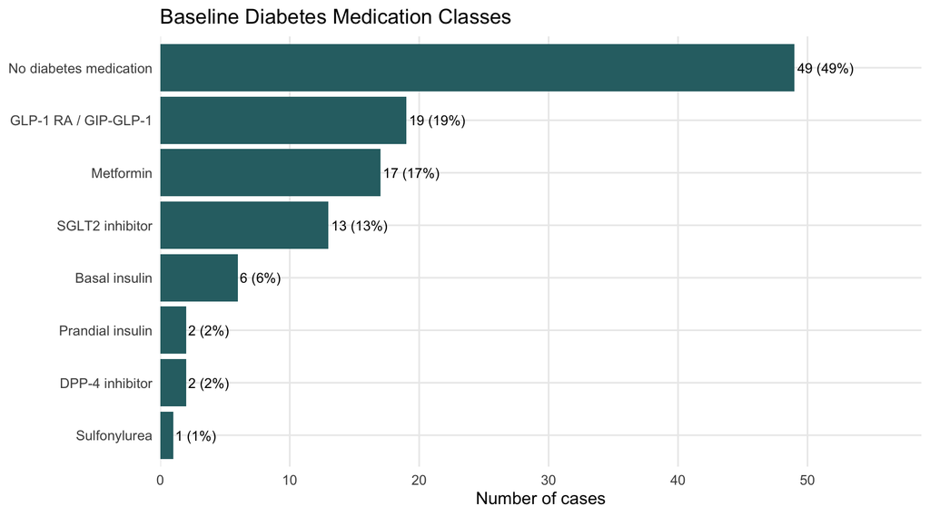

**Key Takeaway:** Baseline medication percentages can sum to more than 100% because patients may be on combination regimens. The no-medication group represents patients with `current_dm_drugs` recorded as `none` or blank.

# Missingness and Data Quality

Missingness in Key Case-Level Variables

| Variable | Missing (n) | Missing (%) |
| --- | --- | --- |
| stage_ckd | 45 | 45 |
| duration_dm_years | 1 | 1 |
| age | 0 | 0 |
| bmi_kg_m2 | 0 | 0 |
| case_id | 0 | 0 |
| chronic_kidney_disease | 0 | 0 |
| current_dm_drugs | 0 | 0 |
| egfr_ml_min_1_73m2 | 0 | 0 |
| financial_limitations | 0 | 0 |
| hba1c_percent | 0 | 0 |
| heart_failure_present | 0 | 0 |
| race_ethnicity | 0 | 0 |
| reluctant_injections | 0 | 0 |
| sex | 0 | 0 |
| uacr_mg_g | 0 | 0 |
| vignette_text | 0 | 0 |

Incomplete Cases (expected = 3 model responses)

[output not shown]

Duplicated Case-Model Combinations (expected = 1 row each)

[output not shown]

DM026 Case Labels in Current Dataset

| Case ID | Vignette text |
| --- | --- |
| DM026(1) | A 65-year-old White female presents after being diagnosed with type 2 diabetes during routine laboratory testing performed at her annual primary care visit. She has not previously taken any diabetes m… |
| DM026(2) | A 65-year-old White male presents after being diagnosed with type 2 diabetes during routine laboratory testing performed at his annual primary care visit. He has not previously taken any diabetes medi… |
| DM026(3) | A 68-year-old White female presents after being diagnosed with type 2 diabetes during evaluation for progressive fatigue, nocturia, and unintentional 12-pound weight loss over the past 4 months. She h… |

**Key Takeaway:** The previous DM026 labeling problem is resolved in this raw dataset because the three variants are represented as `DM026(1)`, `DM026(2)`, and `DM026(3)`. All 100 cases have the expected three model responses.